# Phase II - District Characteristics by Change Group

Janette Avelar

2026-01-08

# Survey Task

In this analysis, we are interested in the guiding question: **How does context relate to change groups?**

There are 4 change groups, defined as:  
- 0 changes underway  
- 1-2 changes underway  
- 3-5 changes underway  
- 6-9 changes underway

This file looks at district characteristics, comparing the mean and distribution of state, district size (enrollment), district size (number of schools), serve high school, enrollment change, racial composition (% White), % low inc, % EL % SWD, student outcomes by change group.

**Note**: *There are 8 districts that do not fall into a change group and I’m not totally sure why – I checked their responses for Q4-6, and 2 of the districts had responded to all 3, while some seem due to missingness. Would be good to talk about who these districts are and why they’re missing.*

| qcode | partial | state | total_domains_working | change_group |
| --- | --- | --- | --- | --- |
| 30001 | 1 | MA | NA | NA |
| 30226 | 1 | MA | NA | NA |
| 30326 | 1 | MA | NA | NA |
| 30378 | 1 | VT | NA | NA |
| 30491 | 1 | MA | NA | NA |
| 30624 | 1 | RI | NA | NA |
| 30741 | 1 | CT | NA | NA |
| 30878 | 1 | NH | NA | NA |

| qcode | q6_1 | q6_2 | q6_3 | q6_4 | q6_5 | q6_6 | q6_7 | q6_8 | q6_9 | q6_10 | q6_11 | q6_12 | q6_13 | q6_14 | q6_15 | q6_16 | q6_17 |
| --- | --- | --- | --- | --- | --- | --- | --- | --- | --- | --- | --- | --- | --- | --- | --- | --- | --- |
| 30001 | NA | NA | NA | NA | NA | NA | NA | NA | NA | NA | NA | NA | NA | NA | NA | NA | NA |
| 30226 | NA | NA | NA | NA | NA | NA | NA | NA | NA | NA | NA | NA | NA | NA | NA | NA | NA |
| 30326 | NA | NA | NA | NA | NA | NA | NA | NA | NA | NA | NA | NA | NA | NA | NA | NA | NA |
| 30378 | NA | NA | NA | NA | NA | NA | NA | NA | NA | NA | NA | NA | NA | NA | NA | NA | NA |
| 30491 | NA | NA | NA | NA | NA | NA | NA | NA | NA | NA | NA | NA | NA | NA | NA | NA | NA |
| 30624 | NA | 1 | NA | NA | NA | NA | NA | NA | NA | NA | NA | NA | NA | NA | NA | 1 | NA |
| 30741 | NA | 1 | NA | NA | NA | 1 | NA | 1 | NA | NA | NA | NA | NA | NA | NA | NA | NA |
| 30878 | NA | NA | NA | NA | NA | NA | NA | NA | NA | NA | NA | NA | NA | NA | NA | NA | NA |

# A1 By state

There are 6 states in our data:

| Var1 | Freq |
| --- | --- |
| CT | 50 |
| MA | 101 |
| ME | 51 |
| NH | 43 |
| RI | 18 |
| VT | 36 |

The percentages in this table represent the distribution within a given state, e.g., *“In Connecticut, 18% of districts were not undergoing change (0 domains) while 6% had high change (6-9 domains).”*

|  | state | 0 domains | 1-2 domains | 3-5 domains | 6-9 domains |
| --- | --- | --- | --- | --- | --- |
| 1 | Connecticut | 0.18 | 0.34 | 0.42 | 0.06 |
| 2 | Massachusetts | 0.1 | 0.36 | 0.44 | 0.11 |
| 3 | Maine | 0.18 | 0.47 | 0.27 | 0.08 |
| 4 | New Hampshire | 0.21 | 0.35 | 0.42 | 0.02 |
| 5 | Rhode Island | 0.11 | 0.44 | 0.28 | 0.17 |
| 6 | Vermont | 0.08 | 0.36 | 0.44 | 0.11 |

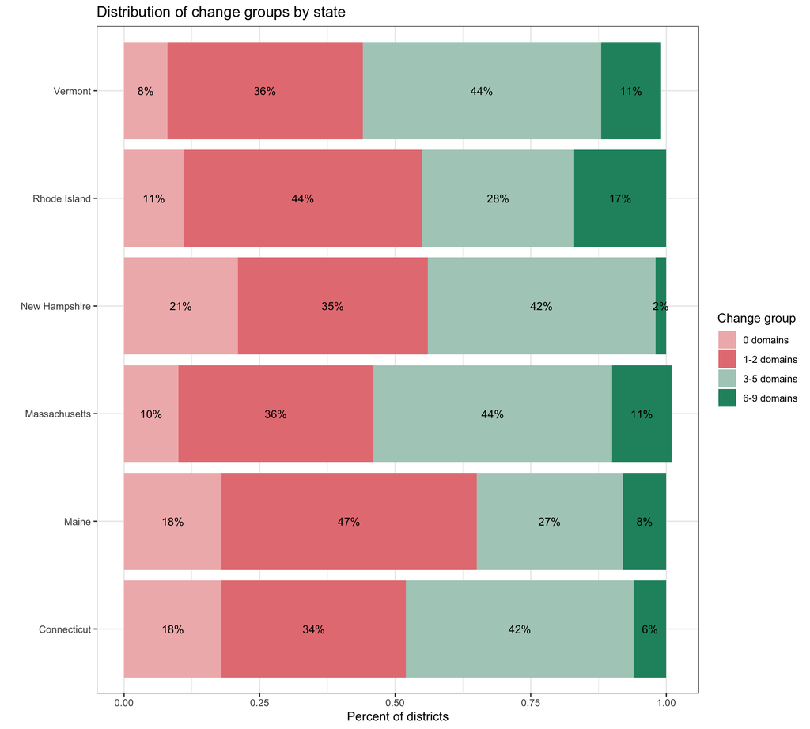

When we break out the distribution of states within change group, we see that high change (3-5 domains or 6-9 domains) is concentrated in Massachusetts (37% and 42% respectively).

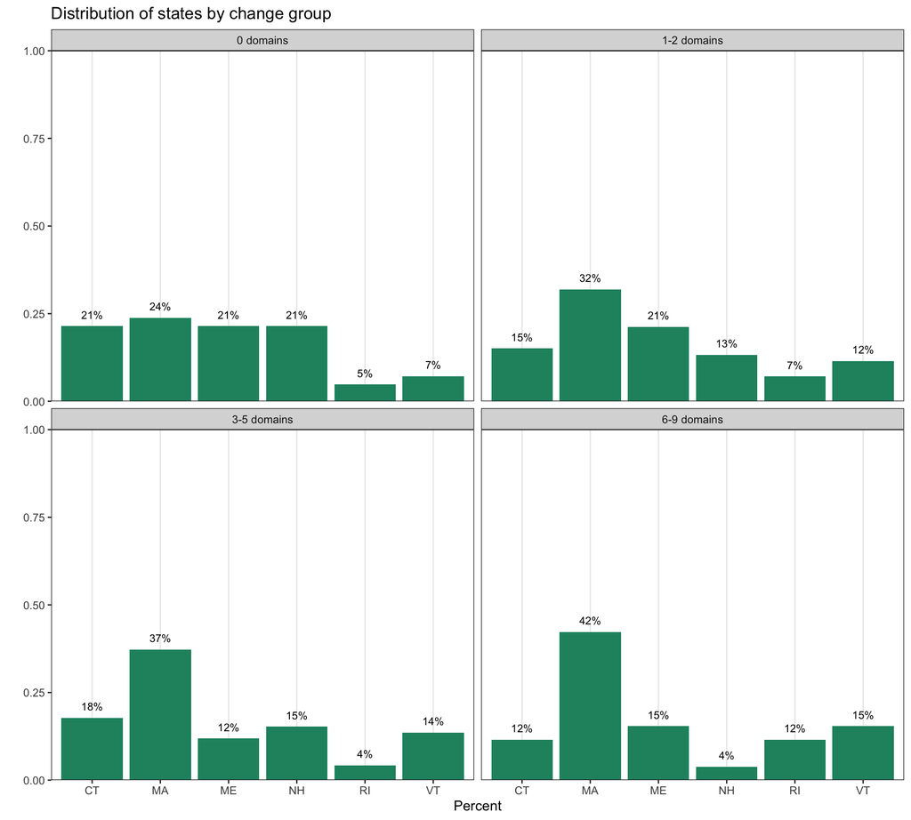

We also want to know if these means are statistically significant from one another. Given we are accounting for state, I ran a chi-square test. Although the share of districts in each change group varies across states, there is no evidence the distribution differs significantly by change group across states.

```
##
##  Pearson's Chi-squared test
##
## data:  tab
## X-squared = 14.339, df = 15, p-value = 0.5
```

```
##
##       0 domains 1-2 domains 3-5 domains 6-9 domains
##   CT  0.8815505  -0.6060916   0.4018924  -0.7412897
##   MA -1.4735180  -0.5473830   1.0358161   0.9622498
##   ME  0.8124671   1.4985496  -1.9273911  -0.2372466
##   NH  1.4038912  -0.4251648   0.3473376  -1.6021283
##   RI -0.3697533   0.6003901  -1.0464453   1.2380423
##   VT -1.0519386  -0.2218653   0.6517649   0.5484182
```

# A2 By district size

## Defined as enrollment

|  | n | mean | sd | min | max |
| --- | --- | --- | --- | --- | --- |
| X1 | 296 | 2011.858 | 2309.639 | 30 | 20250 |

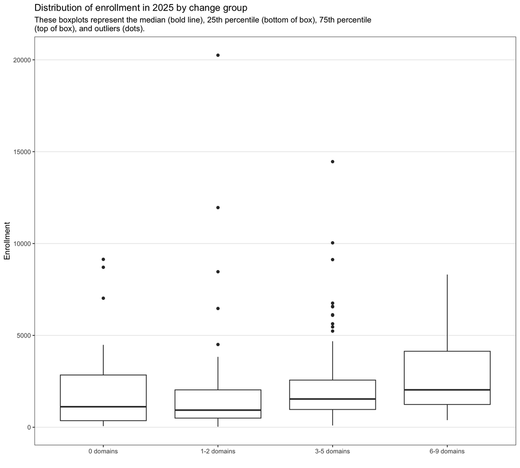

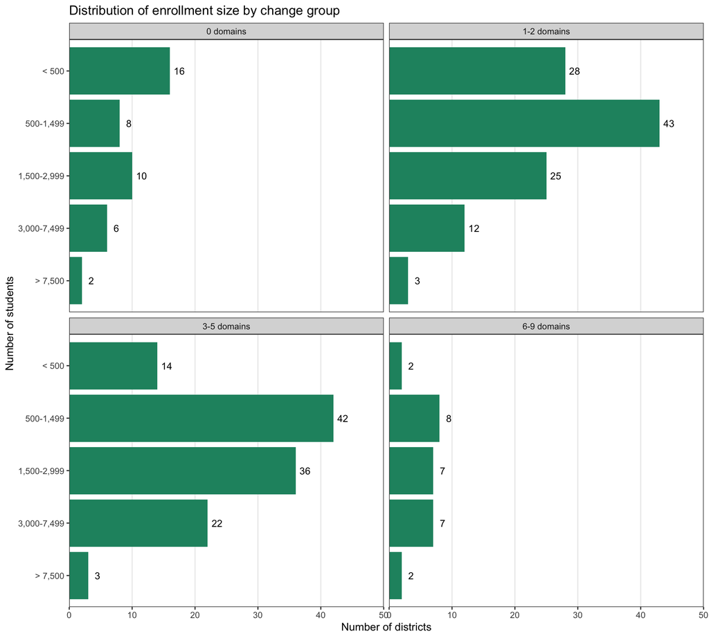

There is not strong statistical evidence that enrollment size differs by change group, although the overall test is marginal (p ≈ .055).

```
##
## Call:
## lm(formula = enrollment_2025 ~ change_group, data = clean)
##
## Residuals:
##     Min      1Q  Median      3Q     Max
## -2541.3 -1289.7  -691.0   474.1 18596.5
##
## Coefficients:
##                         Estimate Std. Error t value Pr(>|t|)
## (Intercept)               1894.1      353.6   5.357 1.72e-07 ***
## change_group1-2 domains   -240.6      415.1  -0.580   0.5626
## change_group3-5 domains    296.2      412.2   0.719   0.4729
## change_group6-9 domains   1035.3      571.8   1.811   0.0712 .
## ---
## Signif. codes:  0 '***' 0.001 '**' 0.01 '*' 0.05 '.' 0.1 ' ' 1
##
## Residual standard error: 2291 on 292 degrees of freedom
##   (3 observations deleted due to missingness)
## Multiple R-squared:  0.02571,    Adjusted R-squared:  0.0157
## F-statistic: 2.568 on 3 and 292 DF,  p-value: 0.05462
```

## Defined as number of schools

The table below includes descriptive statistics for the number of schools and number of high schools districts have:

|  | n | mean | sd | min | max |
| --- | --- | --- | --- | --- | --- |
| num_schools | 299 | 5.234114 | 4.823604 | 1 | 37 |
| num_high_schools | 299 | 1.204013 | 1.301206 | 0 | 12 |

|  | change_group | group | mean | sd | min | max |
| --- | --- | --- | --- | --- | --- | --- |
| 1 | 0 domains | High school | 1.21 | 1.94 | 0 | 12 |
| 2 | 0 domains | All schools | 5.45 | 6.31 | 1 | 32 |
| 3 | 1-2 domains | High school | 1.01 | 1.31 | 0 | 12 |
| 4 | 1-2 domains | All schools | 4.4 | 4.57 | 1 | 37 |
| 5 | 3-5 domains | High school | 1.32 | 0.95 | 0 | 5 |
| 6 | 3-5 domains | All schools | 5.58 | 4.28 | 1 | 27 |
| 7 | 6-9 domains | High school | 1.5 | 1.3 | 0 | 5 |
| 8 | 6-9 domains | All schools | 6.92 | 5.07 | 1 | 20 |

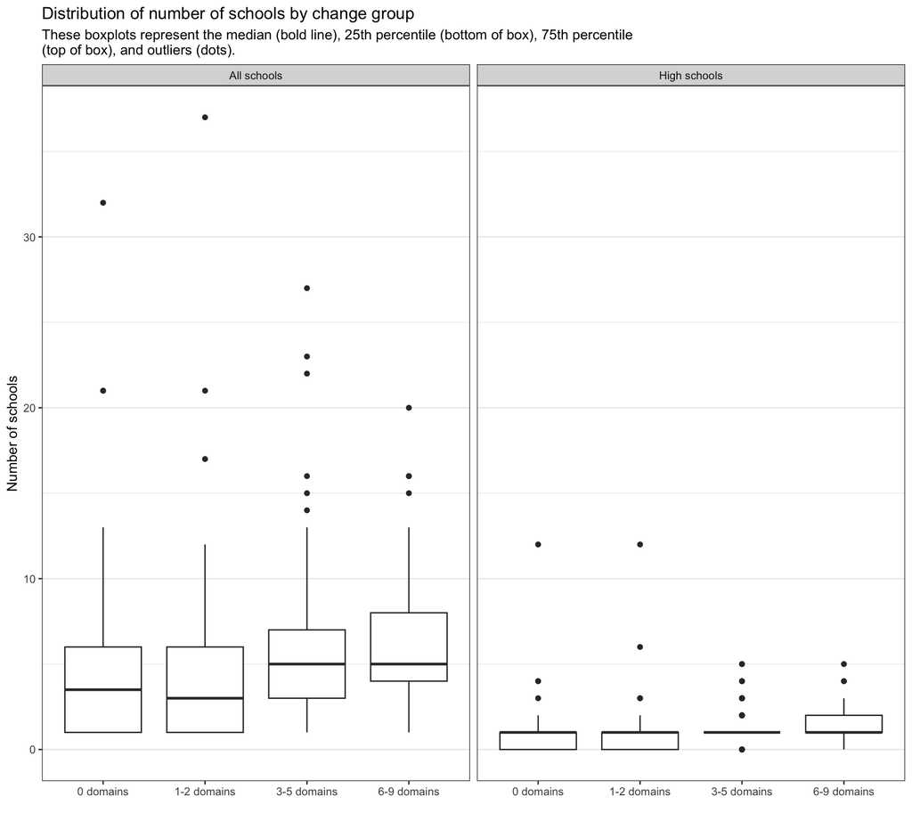

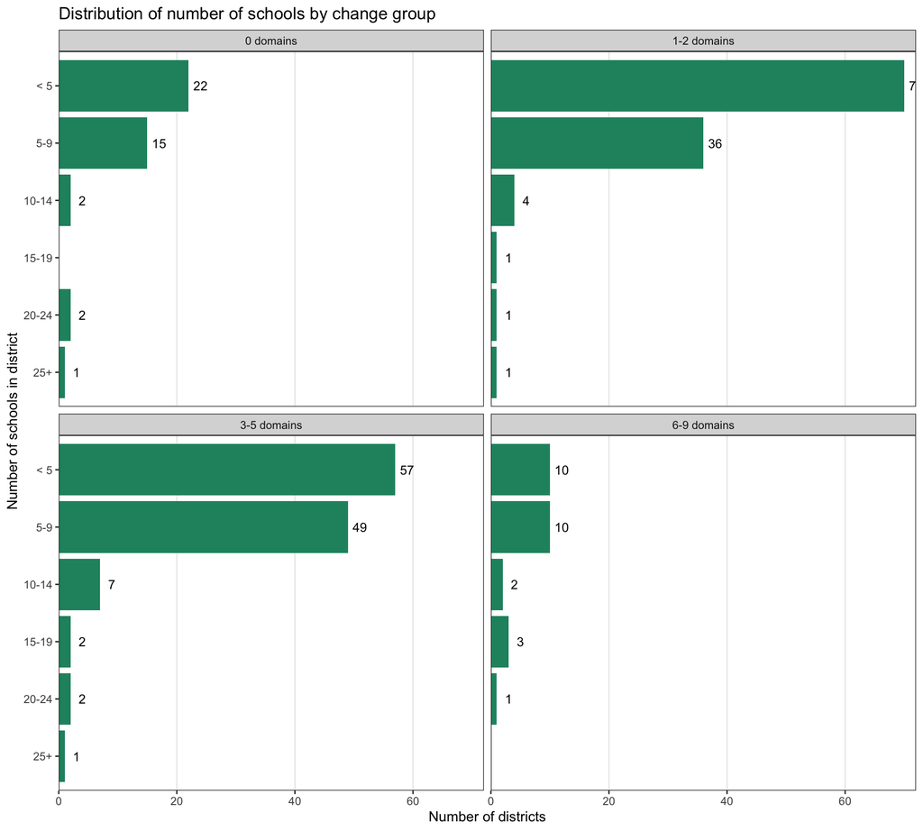

There is not strong statistical evidence that enrollment size differs by the number of schools in the district (p ≈ .06).

```
##
## Call:
## lm(formula = num_schools ~ change_group, data = clean)
##
## Residuals:
##    Min     1Q Median     3Q    Max
## -5.923 -3.398 -1.398  1.415 32.602
##
## Coefficients:
##                         Estimate Std. Error t value Pr(>|t|)
## (Intercept)               5.4524     0.7389   7.379 1.63e-12 ***
## change_group1-2 domains  -1.0542     0.8654  -1.218    0.224
## change_group3-5 domains   0.1324     0.8604   0.154    0.878
## change_group6-9 domains   1.4707     1.1949   1.231    0.219
## ---
## Signif. codes:  0 '***' 0.001 '**' 0.01 '*' 0.05 '.' 0.1 ' ' 1
##
## Residual standard error: 4.788 on 295 degrees of freedom
## Multiple R-squared:  0.02446,    Adjusted R-squared:  0.01454
## F-statistic: 2.466 on 3 and 295 DF,  p-value: 0.06239
```

# A3 By serving high school

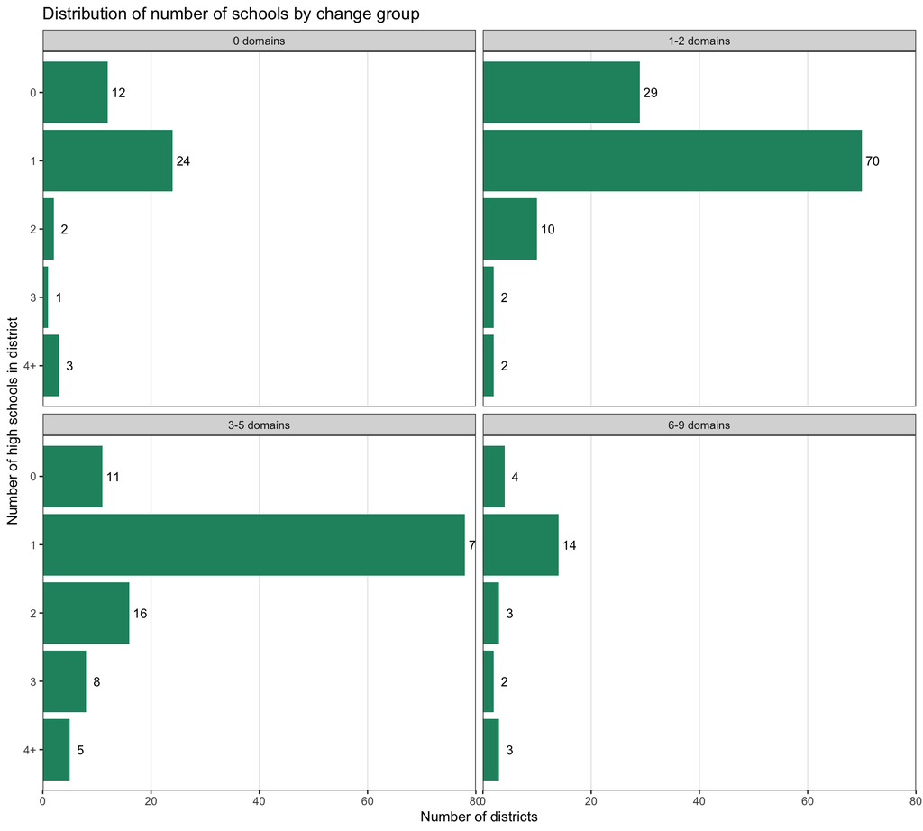

There is not strong statistical evidence that enrollment size differs by the number of high schools in the district (p ≈ .18).

```
##
## Call:
## lm(formula = num_high_schools ~ change_group, data = clean)
##
## Residuals:
##     Min      1Q  Median      3Q     Max
## -1.5000 -0.3220 -0.2143 -0.0088 10.9912
##
## Coefficients:
##                         Estimate Std. Error t value Pr(>|t|)
## (Intercept)               1.2143     0.2001   6.067 3.99e-09 ***
## change_group1-2 domains  -0.2054     0.2344  -0.876    0.382
## change_group3-5 domains   0.1077     0.2331   0.462    0.644
## change_group6-9 domains   0.2857     0.3237   0.883    0.378
## ---
## Signif. codes:  0 '***' 0.001 '**' 0.01 '*' 0.05 '.' 0.1 ' ' 1
##
## Residual standard error: 1.297 on 295 degrees of freedom
## Multiple R-squared:  0.01631,    Adjusted R-squared:  0.006308
## F-statistic: 1.631 on 3 and 295 DF,  p-value: 0.1824
```

## By enrollment change

```
##    vars   n  mean   sd median trimmed  mad   min  max range skew kurtosis   se
## X1    1 288 -0.04 0.12  -0.05   -0.05 0.07 -0.31 0.87  1.18 2.96    17.08 0.01
```

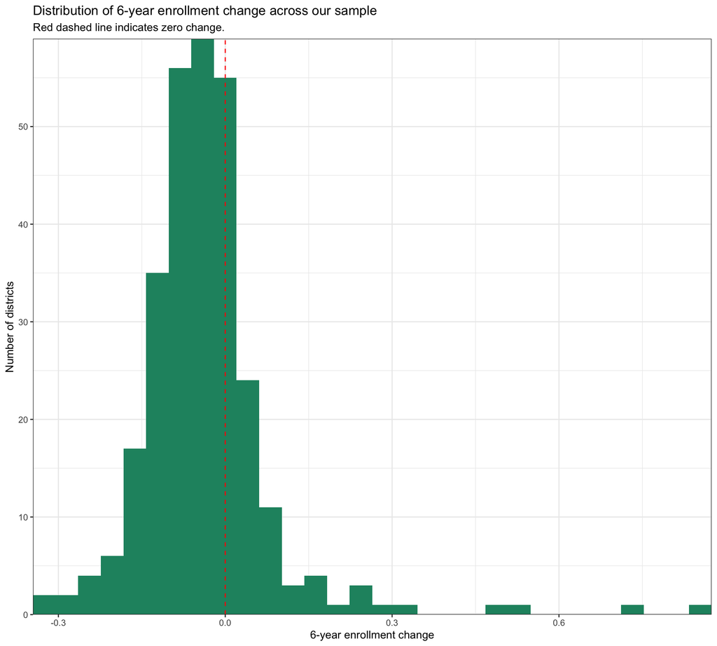

When we break out enrollment change by change group, we don’t see any obvious differences in the pattern of loss. Districts with a higher degree of change (6-9 domains) are experiencing a slightly higher rate of loss compared to other groups (6%).

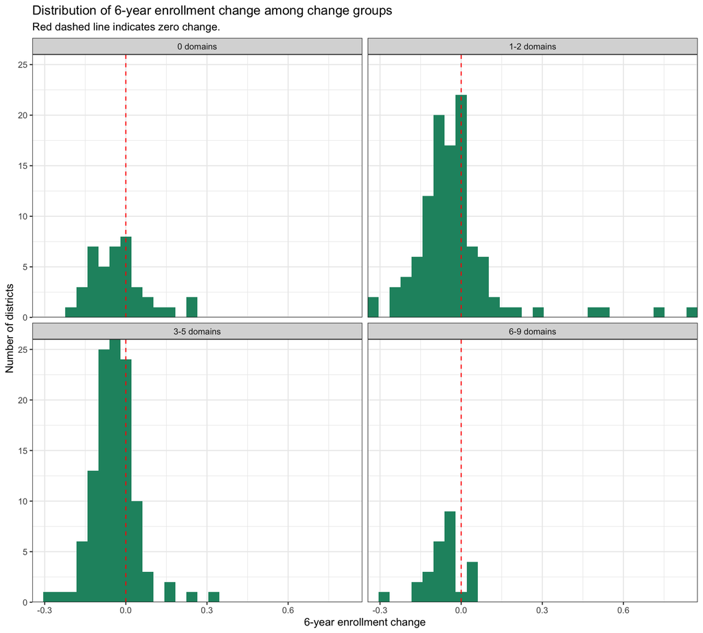

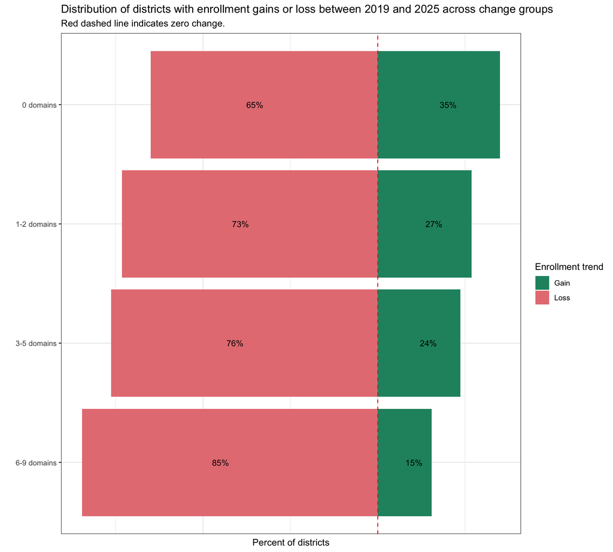

There is not strong statistical evidence that the 6-year change in enrollment differs by the number of schools in the district (p ≈ .4).

```
##
## Call:
## lm(formula = enrollment_change_6yr_pct ~ change_group, data = clean)
##
## Residuals:
##      Min       1Q   Median       3Q      Max
## -0.28667 -0.06057 -0.00453  0.04038  0.89263
##
## Coefficients:
##                          Estimate Std. Error t value Pr(>|t|)
## (Intercept)             -0.034514   0.019522  -1.768   0.0781 .
## change_group1-2 domains  0.011446   0.022853   0.501   0.6169
## change_group3-5 domains -0.009488   0.022690  -0.418   0.6761
## change_group6-9 domains -0.029099   0.031103  -0.936   0.3503
## ---
## Signif. codes:  0 '***' 0.001 '**' 0.01 '*' 0.05 '.' 0.1 ' ' 1
##
## Residual standard error: 0.1235 on 284 degrees of freedom
##   (11 observations deleted due to missingness)
## Multiple R-squared:  0.01033,    Adjusted R-squared:  -0.0001291
## F-statistic: 0.9877 on 3 and 284 DF,  p-value: 0.399
```

# A3 By grades served

We have data for grades served for 299 districts (0 missing). The categories are broken into:  
- K-6  
- K-8  
- K-12  
- 6-8  
- 7-12  
- 9-12

Counts by grade band are displayed in the table below:

```
##
##  6-8 7-12 9-12 K-12  K-6  K-8
##    3   11   16  216   14   39
```

Unsurprisingly, once we break out by change group we see that the majority of districts are falling into the K-12 grade band by change group. This is overwhelmingly the case for those districts implementing a lot of change (3-5 or 6-9 domains). Among districts focusing on just 1 or 2 domains, 1 in 5 is a district that serves only K-8 grades. Among districts that are not currently focusing on any domains, a quarter serve only K-6 or K-8 grades.

This could indicate that districts serving high school grades, and particularly full K-12 grades, tend to take on more change work while those serving primary and middle school grades focus on far less, if any, change work.

The chart below breaks out percentages differently than the table above. Here, the distribution of change groups is broken out by grades served (rather than looking at grades served broken out by change group).

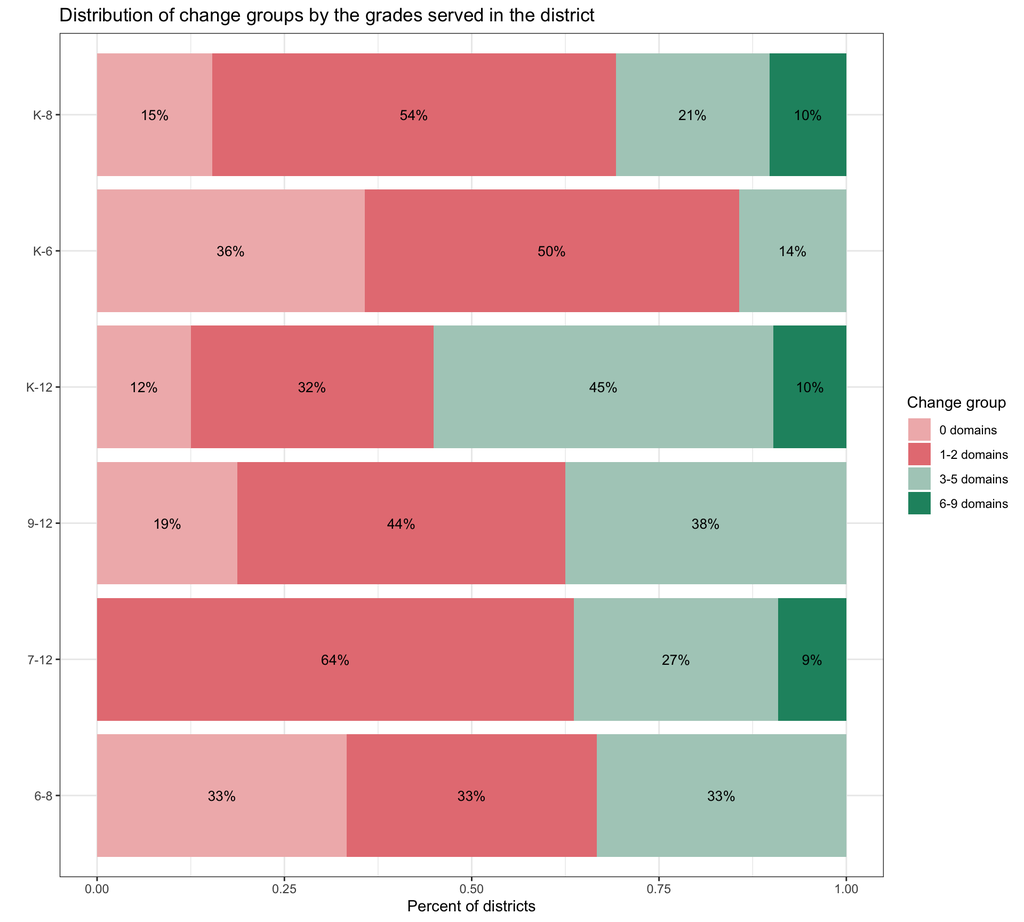

According to the chi-square test, the change groups do differ meaningfully based on the grades served in the district (p < .05). My initial thoughts are that this is due to cell sizes with 0 values as well as overlap in the grade bands. For future research, I’d suggest using the “serves high school grades” variable only.

```
##
##  Pearson's Chi-squared test
##
## data:  tab
## X-squared = 26.076, df = 15, p-value = 0.03723
```

```
##
##          0 domains 1-2 domains 3-5 domains 6-9 domains
##   6-8   0.96623776 -0.16010077 -0.21837932 -0.53722438
##   7-12 -1.36613550  1.80121784 -0.84296024  0.04740437
##   9-12  0.55651093  0.50516302 -0.16528367 -1.26884250
##   K-12 -1.24177798 -3.09815796  3.37031172  1.01628427
##   K-6   2.38982019  0.96488233 -1.97428327 -1.18272161
##   K-8   0.25783983  2.21731179 -2.59674079  0.37095396
```

# A4 By district type

We have district type data for all districts, and counts by type are in the table below:

```
##
##      Charter     Regional Regional CTE State agency  Traditional
##           32           41           10            2          214
```

The chart below breaks out percentages differently than the table above. Here, the distribution of change groups is broken out by school type (rather than looking at school type broken out by change group).

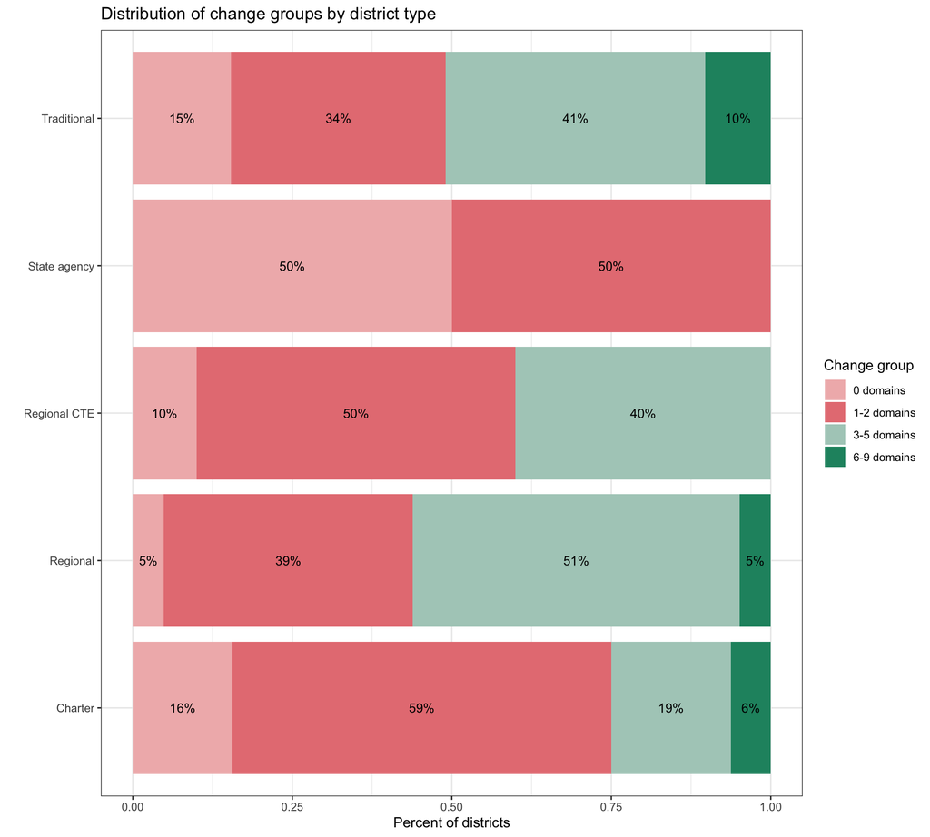

There is not evidence that change groups differ meaningfully by district type according to the chi square results below (p = .101).

```
##
##  Pearson's Chi-squared test
##
## data:  tab
## X-squared = 18.513, df = 12, p-value = 0.101
```

```
##
##                  0 domains 1-2 domains 3-5 domains 6-9 domains
##   Charter       0.27188842  2.66458351 -2.53704595 -0.51958049
##   Regional     -1.81890039  0.17511166  1.65774414 -0.93392428
##   Regional CTE -0.37461127  0.80981132  0.03521489 -0.99264057
##   State agency  1.46821489  0.35724778 -1.14570836 -0.43790280
##   Traditional   1.08471816 -2.34706150  0.66761119  1.54308270
```

# A5 By urbanicity

We have urbanicity data for all districts, and counts by type are in the table below:

```
##
##    Rural Suburban    Urban
##      160      111       28
```

When we break this out by group, rural areas make up the highest proportion for all groups except for those with 6-9 domains. Among those with 6-9 domains, nearly half are suburban districts.

The chart below breaks out percentages differently than the table above. Here, the distribution of change groups is broken out by urbanicity (rather than looking at urbanicity broken out by change group).

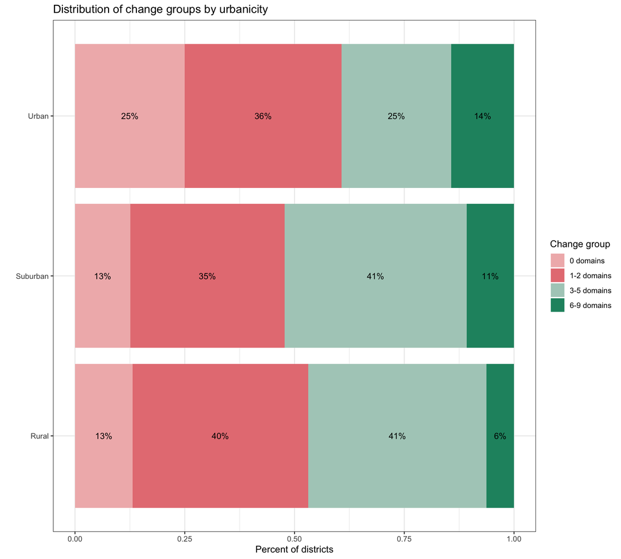

There is not evidence that change groups differ meaningfully by urbanicity according to the chi square results below (p = .28).

```
##
##  Pearson's Chi-squared test
##
## data:  tab
## X-squared = 7.4233, df = 6, p-value = 0.2835
```

```
##
##             0 domains 1-2 domains 3-5 domains 6-9 domains
##   Rural    -0.4921705   0.8445715   0.4403327  -1.6102232
##   Suburban -0.5484170  -0.7282292   0.5373023   0.9973884
##   Urban     1.7520644  -0.2382459  -1.6448859   1.1026807
```

# A6 By racial composition

The overall descriptives for our sample are in the table below:

```
##                 vars   n mean   sd median trimmed  mad min  max range  skew
## pct_white          1 296 0.73 0.26   0.83    0.78 0.14   0 1.00  1.00 -1.47
## pct_black          2 296 0.06 0.11   0.02    0.03 0.02   0 0.84  0.84  3.84
## pct_hispanic       3 296 0.14 0.18   0.07    0.10 0.07   0 0.99  0.99  2.23
## pct_aapi           4 296 0.03 0.06   0.01    0.02 0.01   0 0.58  0.58  5.07
## pct_aian           5 295 0.00 0.01   0.00    0.00 0.00   0 0.07  0.07  3.95
## pct_multiracial    6 296 0.04 0.02   0.04    0.04 0.02   0 0.18  0.18  1.56
##                 kurtosis   se
## pct_white           1.03 0.02
## pct_black          17.50 0.01
## pct_hispanic        4.58 0.01
## pct_aapi           36.01 0.00
## pct_aian           18.34 0.00
## pct_multiracial     5.83 0.00
```

When we break out descriptives by change group we see that districts undergoing more change (6-9 domains) tend to have higher populations of BIPOC students and combined Black/Hispanic student populations.

[interactive table not shown]

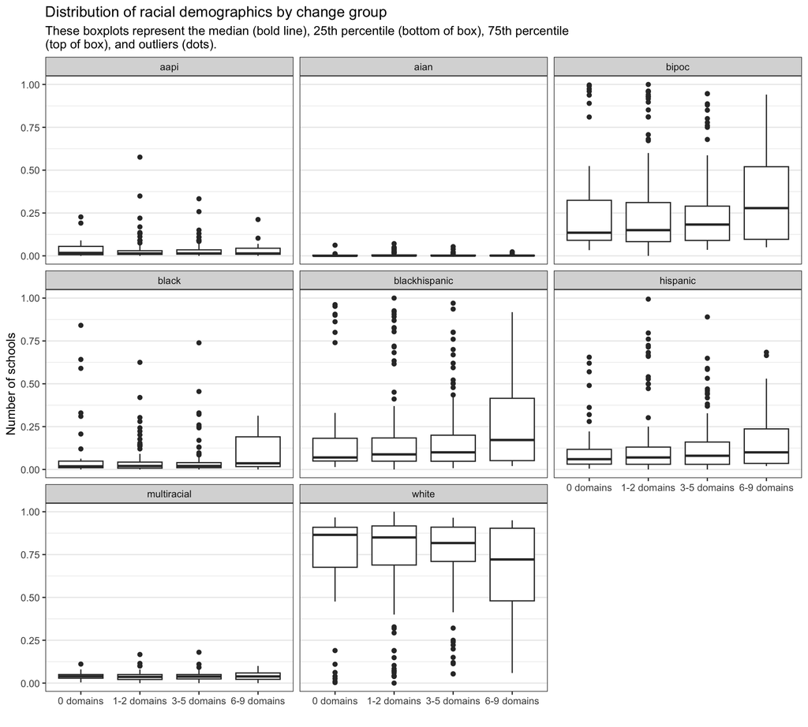

There is not strong statistical evidence that racial demographics differ by change group.

|  | % AAPI | % AIAN | % BIPOC | % Black | % Hispanic | % Black & Hispanic | % White |
| --- | --- | --- | --- | --- | --- | --- | --- |
| (Intercept) | 0.035 | 0.003 | 0.291 | 0.088 | 0.128 | 0.216 | 0.709 |
|  | (0.009) | (0.001) | (0.040) | (0.017) | (0.028) | (0.038) | (0.040) |
| change_group1-2 domains | -0.001 | 0.002 | -0.025 | -0.040 | 0.014 | -0.027 | 0.025 |
|  | (0.010) | (0.002) | (0.048) | (0.020) | (0.033) | (0.045) | (0.048) |
| change_group3-5 domains | -0.004 | 0.000 | -0.040 | -0.040 | 0.003 | -0.037 | 0.040 |
|  | (0.010) | (0.002) | (0.047) | (0.020) | (0.033) | (0.045) | (0.047) |
| change_group6-9 domains | -0.001 | 0.000 | 0.071 | 0.009 | 0.054 | 0.063 | -0.071 |
|  | (0.014) | (0.002) | (0.065) | (0.028) | (0.045) | (0.062) | (0.065) |
| Num.Obs. | 296 | 295 | 296 | 296 | 296 | 296 | 296 |
| R2 | 0.001 | 0.013 | 0.014 | 0.027 | 0.006 | 0.013 | 0.014 |
| R2 Adj. | -0.009 | 0.003 | 0.004 | 0.017 | -0.004 | 0.003 | 0.004 |
| AIC | -858.5 | -1904.1 | 54.0 | -450.9 | -166.1 | 21.5 | 54.0 |
| BIC | -840.0 | -1885.7 | 72.5 | -432.5 | -147.7 | 39.9 | 72.5 |
| Log.Lik. | 434.225 | 957.050 | -22.009 | 230.454 | 88.058 | -5.737 | -22.009 |
| F | 0.084 | 1.309 | 1.366 | 2.683 | 0.615 | 1.256 | 1.366 |
| RMSE | 0.06 | 0.01 | 0.26 | 0.11 | 0.18 | 0.25 | 0.26 |

## By % low income

We have data from 296 districts (3 missing) for the percentage of students considered low income by eligibility for free and reduced-price lunch. Overall descriptives are in the table below:

|  | n | mean | sd | min | max |
| --- | --- | --- | --- | --- | --- |
| X1 | 296 | 0.3766931 | 0.2089786 | 0 | 1 |

When we break this out by change group there is a slight pattern of increasing low-income students by number of domains adopted, but the difference is quite small.

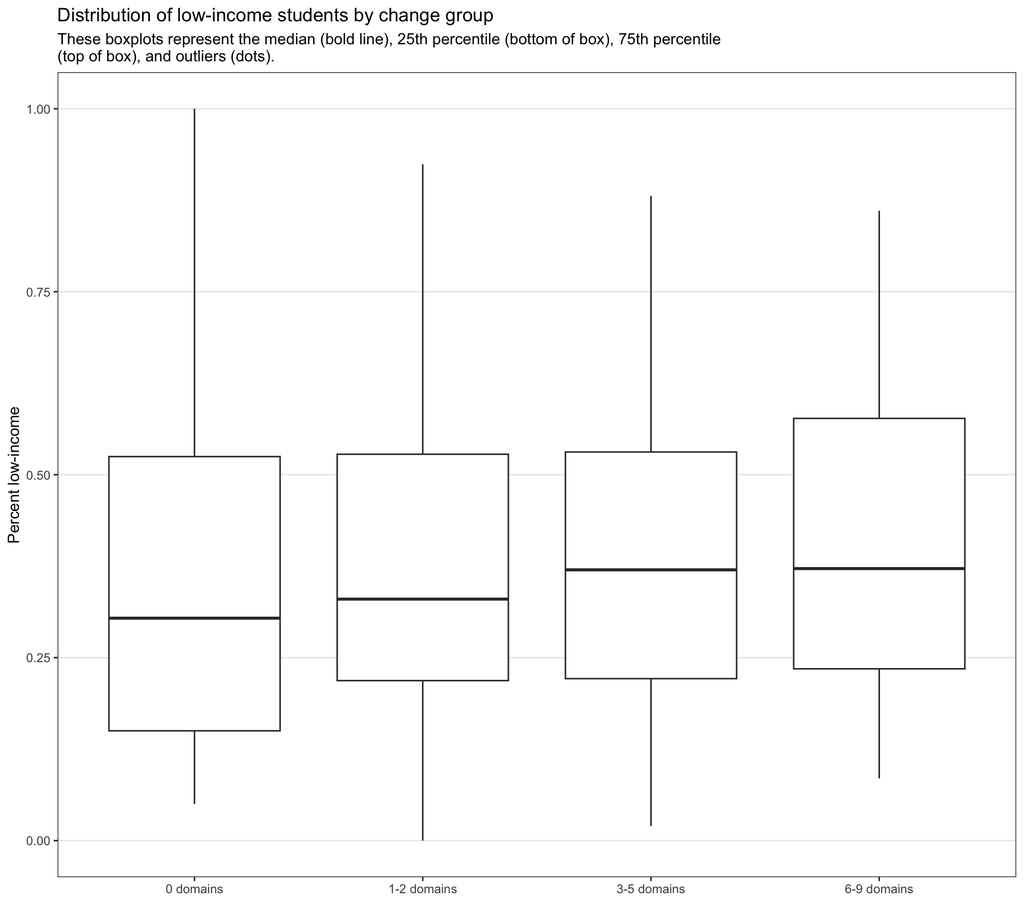

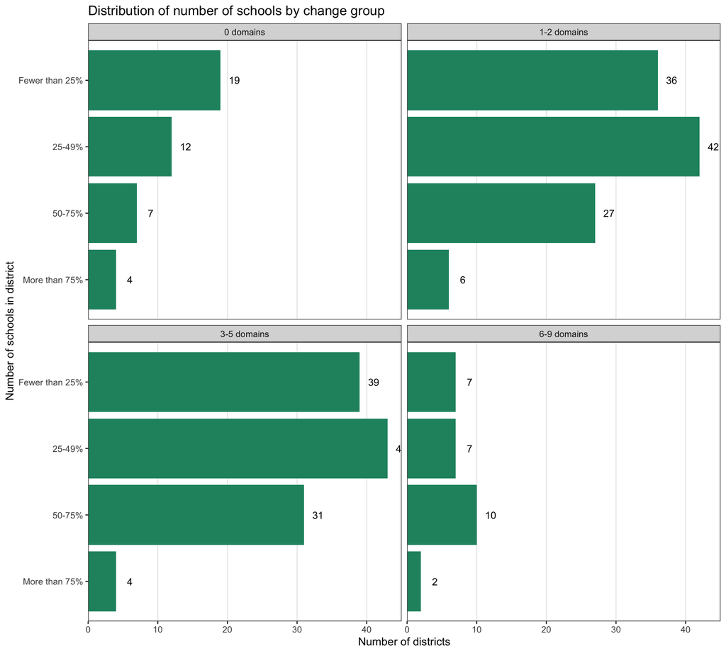

```
##
## Call:
## lm(formula = pct_lowinc ~ change_group, data = clean)
##
## Residuals:
##      Min       1Q   Median       3Q      Max
## -0.37023 -0.16146 -0.02961  0.15648  0.63873
##
## Coefficients:
##                         Estimate Std. Error t value Pr(>|t|)
## (Intercept)             0.361275   0.032310  11.182   <2e-16 ***
## change_group1-2 domains 0.008958   0.037933   0.236    0.813
## change_group3-5 domains 0.015882   0.037665   0.422    0.674
## change_group6-9 domains 0.065818   0.052252   1.260    0.209
## ---
## Signif. codes:  0 '***' 0.001 '**' 0.01 '*' 0.05 '.' 0.1 ' ' 1
##
## Residual standard error: 0.2094 on 292 degrees of freedom
##   (3 observations deleted due to missingness)
## Multiple R-squared:  0.006263,   Adjusted R-squared:  -0.003947
## F-statistic: 0.6134 on 3 and 292 DF,  p-value: 0.6068
```

## By % EL

We have data from 296 districts (3 missing) for the percentage of students currently classified as English learners. Overall descriptives are in the table below:

|  | n | mean | sd | min | max |
| --- | --- | --- | --- | --- | --- |
| X1 | 296 | 0.0562605 | 0.0944598 | 0 | 0.5184 |

When we break this out by change group we see that the average percentage of EL-designated students in districts adopting more change (6-9 domains) is higher. Districts that are not currently working on any domains had a much smaller range–no districts had more than 21% EL-designated students.

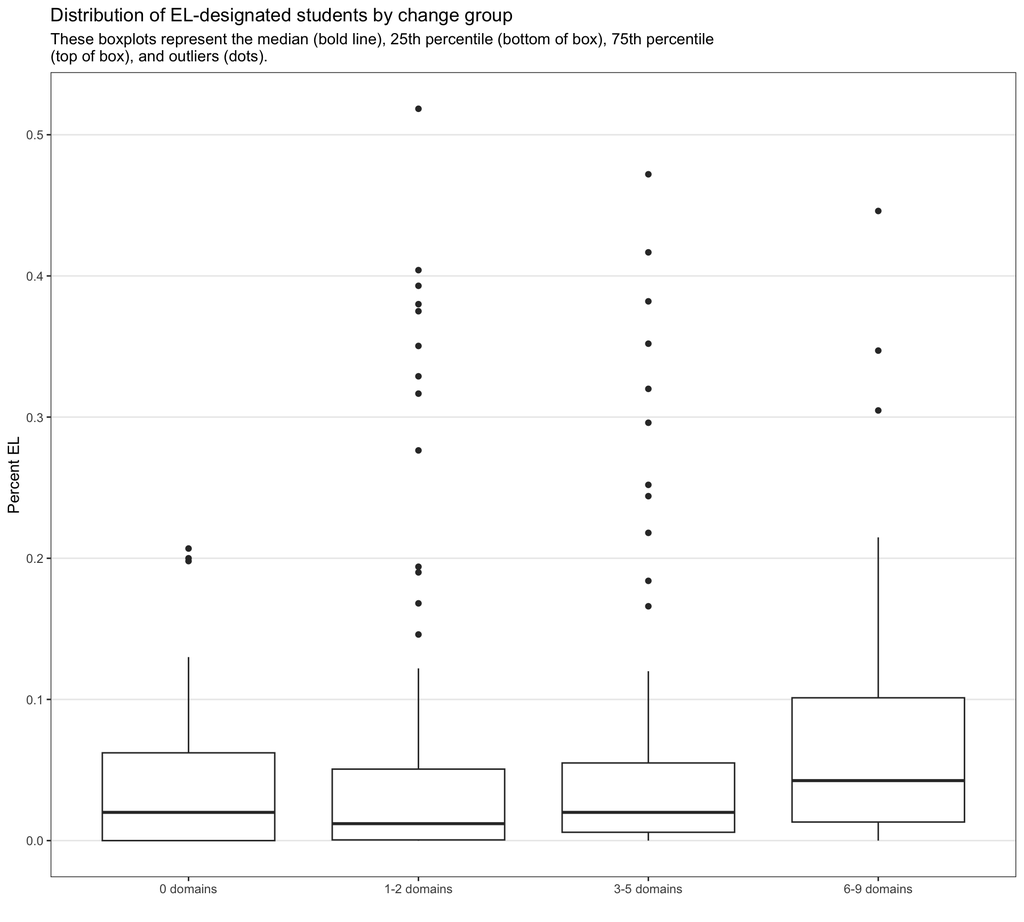

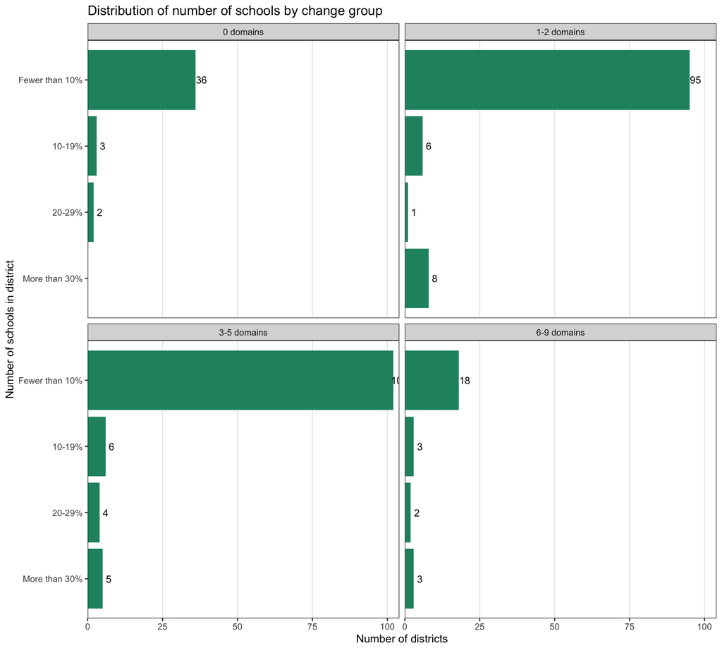

There is not strong statistical evidence that the change group differs by the percentage of EL-designated students in the district (p ≈ .29).

```
##
## Call:
## lm(formula = pct_el ~ change_group, data = clean)
##
## Residuals:
##      Min       1Q   Median       3Q      Max
## -0.08771 -0.05024 -0.03416  0.00383  0.46223
##
## Coefficients:
##                         Estimate Std. Error t value Pr(>|t|)
## (Intercept)              0.04287    0.01456   2.945  0.00349 **
## change_group1-2 domains  0.01331    0.01709   0.779  0.43682
## change_group3-5 domains  0.01129    0.01697   0.665  0.50628
## change_group6-9 domains  0.04484    0.02354   1.905  0.05778 .
## ---
## Signif. codes:  0 '***' 0.001 '**' 0.01 '*' 0.05 '.' 0.1 ' ' 1
##
## Residual standard error: 0.09433 on 292 degrees of freedom
##   (3 observations deleted due to missingness)
## Multiple R-squared:  0.01283,    Adjusted R-squared:  0.002685
## F-statistic: 1.265 on 3 and 292 DF,  p-value: 0.2867
```

## By % SPED

We have data from 290 districts (9 missing) for the percentage of students with disabilities who are receiving special education services. Overall descriptives are in the table below:

|  | n | mean | sd | min | max |
| --- | --- | --- | --- | --- | --- |
| X1 | 290 | 0.1933421 | 0.051558 | 0 | 0.535 |

When we break this out by change group we don’t see notable differences in means or range.

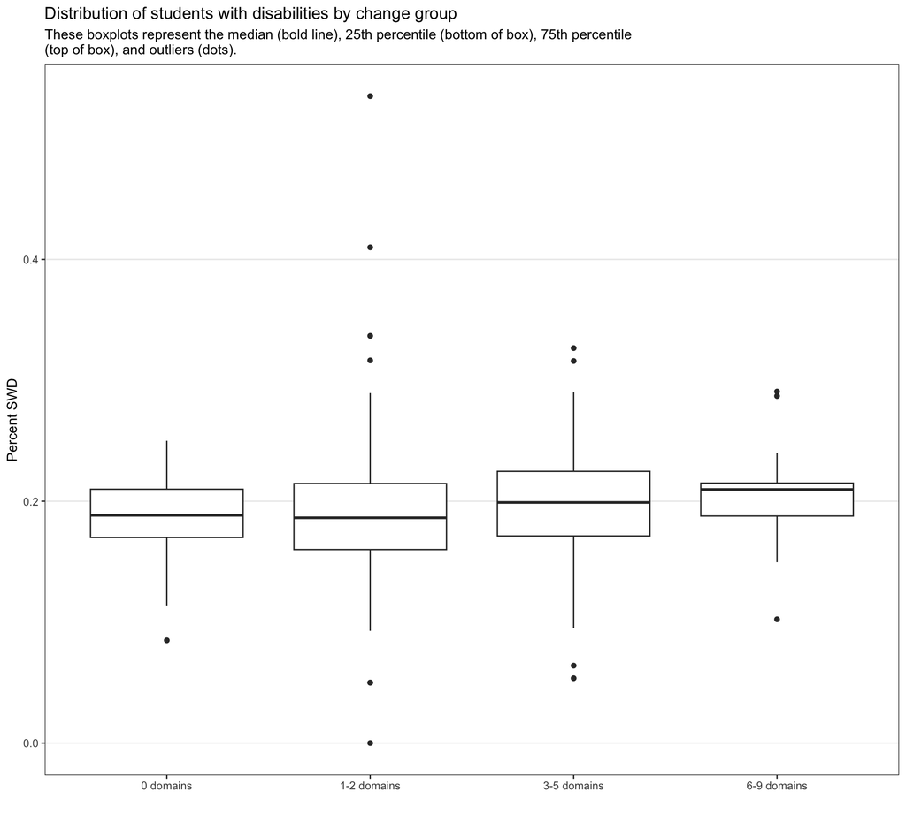

[figure not shown]

```
##
## Call:
## lm(formula = pct_sped ~ change_group, data = clean)
##
## Residuals:
##      Min       1Q   Median       3Q      Max
## -0.18794 -0.02627  0.00118  0.02540  0.34706
##
## Coefficients:
##                         Estimate Std. Error t value Pr(>|t|)
## (Intercept)             0.185690   0.008129  22.843   <2e-16 ***
## change_group1-2 domains 0.002247   0.009504   0.236    0.813
## change_group3-5 domains 0.012703   0.009437   1.346    0.179
## change_group6-9 domains 0.019741   0.012952   1.524    0.129
## ---
## Signif. codes:  0 '***' 0.001 '**' 0.01 '*' 0.05 '.' 0.1 ' ' 1
##
## Residual standard error: 0.05141 on 286 degrees of freedom
##   (9 observations deleted due to missingness)
## Multiple R-squared:  0.01596,    Adjusted R-squared:  0.005637
## F-statistic: 1.546 on 3 and 286 DF,  p-value: 0.2028
```

# A7 By student outcomes

## Math achievement 3-8

**UPDATE: This section has been re-run with centered variable 12.30.25**

We have data on the percentage of students reaching proficiency in math across grades 3-8 for 266 districts (33 missing). The descriptives for the full sample are presented in the table below:

```
##    vars   n mean   sd median trimmed  mad   min  max range skew kurtosis   se
## X1    1 266    0 0.15  -0.01       0 0.16 -0.38 0.43  0.81 0.19    -0.39 0.01
```

When we break out descriptives by change group we see math achievement go down as the number of domains a district is working on increases.

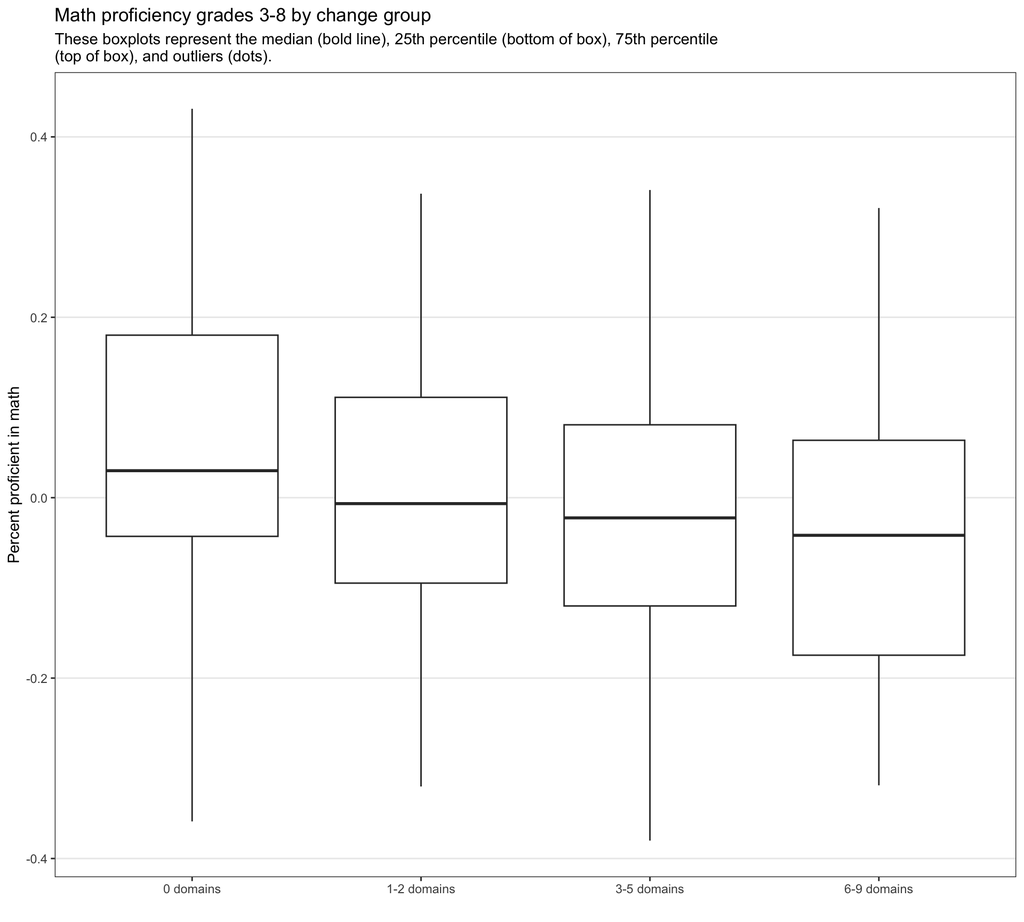

Change groups do seem to differ meaningfully by math proficiency with the original variable (p < .05). There is statistically lower proficiency rates for districts with more change (3-5 domains or 6-9 domains). However, this difference goes away when using the centered version (p = .09)

```
##
## Call:
## lm(formula = pct_math_prof_3_8_center ~ change_group, data = clean)
##
## Residuals:
##      Min       1Q   Median       3Q      Max
## -0.41064 -0.11161 -0.01435  0.09980  0.37936
##
## Coefficients:
##                         Estimate Std. Error t value Pr(>|t|)
## (Intercept)              0.05179    0.02553   2.029   0.0435 *
## change_group1-2 domains -0.04212    0.02985  -1.411   0.1594
## change_group3-5 domains -0.06457    0.02955  -2.185   0.0298 *
## change_group6-9 domains -0.08549    0.03942  -2.169   0.0310 *
## ---
## Signif. codes:  0 '***' 0.001 '**' 0.01 '*' 0.05 '.' 0.1 ' ' 1
##
## Residual standard error: 0.1532 on 262 degrees of freedom
##   (33 observations deleted due to missingness)
## Multiple R-squared:  0.02402,    Adjusted R-squared:  0.01285
## F-statistic: 2.149 on 3 and 262 DF,  p-value: 0.09442
```

## Math achievement 9-12

We have data on the percentage of students reaching proficiency in math across grades 9-12 for 187 districts (112 missing). The descriptives for the full sample are presented in the table below:

```
##    vars   n  mean   sd median trimmed  mad  min  max range skew kurtosis   se
## X1    1 187 -0.01 0.18  -0.02   -0.01 0.19 -0.4 0.44  0.84 0.36    -0.47 0.01
```

When we break out by change group we see the same pattern holds at the secondary level; average math achievement is lower as the number of domains a district is working on increases.

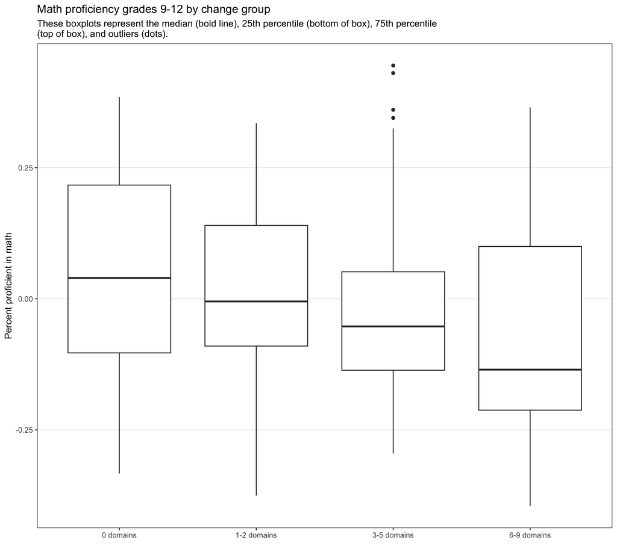

Change groups do not differ meaningfully by math proficiency (p = .2).

```
##
## Call:
## lm(formula = pct_math_prof_9_12_center ~ change_group, data = clean)
##
## Residuals:
##     Min      1Q  Median      3Q     Max
## -0.3887 -0.1235 -0.0271  0.1261  0.4689
##
## Coefficients:
##                         Estimate Std. Error t value Pr(>|t|)
## (Intercept)              0.04393    0.03802   1.155   0.2494
## change_group1-2 domains -0.03037    0.04427  -0.686   0.4937
## change_group3-5 domains -0.06795    0.04232  -1.606   0.1101
## change_group6-9 domains -0.09471    0.05517  -1.717   0.0877 .
## ---
## Signif. codes:  0 '***' 0.001 '**' 0.01 '*' 0.05 '.' 0.1 ' ' 1
##
## Residual standard error: 0.1742 on 183 degrees of freedom
##   (112 observations deleted due to missingness)
## Multiple R-squared:  0.0248, Adjusted R-squared:  0.008818
## F-statistic: 1.552 on 3 and 183 DF,  p-value: 0.2028
```

## Reading achievement 3-8

We have data on the percentage of students reaching proficiency in ELA across grades 3-8 for 266 districts (33 missing). The descriptives for the full sample are presented in the table below:

```
##    vars   n mean   sd median trimmed  mad   min  max range skew kurtosis   se
## X1    1 266    0 0.14   0.01       0 0.14 -0.34 0.36   0.7 0.06    -0.32 0.01
```

When we break out by change group we see the same pattern holds for ELA at the primary level; average reading achievement is lower as the number of domains a district is working on increases, though the magnitude is less severe than it is for math.

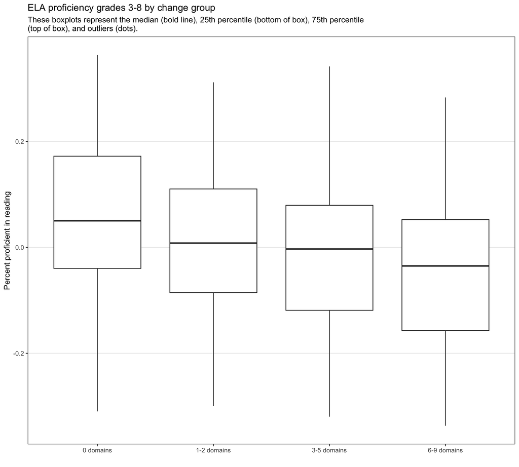

Like with math proficiency in earlier grades, change groups did seem to differ meaningfully by reading proficiency (p < .05). Specifically, districts with more change (3-5 domains and 6-9 domains) are statistically different from those with less change. However, when we use the centered version that difference goes away (p = .12).

```
##
## Call:
## lm(formula = pct_ela_prof_3_8_center ~ change_group, data = clean)
##
## Residuals:
##      Min       1Q   Median       3Q      Max
## -0.35245 -0.10458  0.00284  0.09803  0.35196
##
## Coefficients:
##                         Estimate Std. Error t value Pr(>|t|)
## (Intercept)              0.04273    0.02271   1.882   0.0610 .
## change_group1-2 domains -0.03129    0.02669  -1.172   0.2422
## change_group3-5 domains -0.05297    0.02638  -2.008   0.0456 *
## change_group6-9 domains -0.07347    0.03535  -2.078   0.0386 *
## ---
## Signif. codes:  0 '***' 0.001 '**' 0.01 '*' 0.05 '.' 0.1 ' ' 1
##
## Residual standard error: 0.1381 on 262 degrees of freedom
##   (33 observations deleted due to missingness)
## Multiple R-squared:  0.0222, Adjusted R-squared:  0.011
## F-statistic: 1.983 on 3 and 262 DF,  p-value: 0.1169
```

## Reading achievement 9-12

We have data on the percentage of students reaching proficiency in ELA across grades 9-12 for 187 districts (112 missing). The descriptives for the full sample are presented in the table below:

```
##    vars   n  mean   sd median trimmed  mad   min  max range skew kurtosis   se
## X1    1 187 -0.01 0.17      0       0 0.16 -0.46 0.34   0.8 -0.3    -0.35 0.01
```

The same pattern again holds for reading achievement at the secondary level.

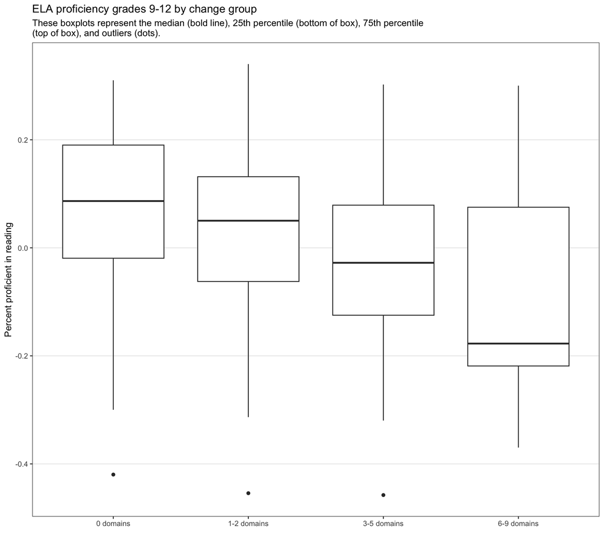

Change groups do seem to differ meaningfully by reading proficiency for secondary students, regardless of the specification (p < .05).

```
##
## Call:
## lm(formula = pct_ela_prof_9_12_center ~ change_group, data = clean)
##
## Residuals:
##      Min       1Q   Median       3Q      Max
## -0.47360 -0.10826  0.01174  0.11813  0.37940
##
## Coefficients:
##                         Estimate Std. Error t value Pr(>|t|)
## (Intercept)              0.05199    0.03613   1.439   0.1519
## change_group1-2 domains -0.03266    0.04198  -0.778   0.4377
## change_group3-5 domains -0.07352    0.04026  -1.826   0.0694 .
## change_group6-9 domains -0.13118    0.05243  -2.502   0.0132 *
## ---
## Signif. codes:  0 '***' 0.001 '**' 0.01 '*' 0.05 '.' 0.1 ' ' 1
##
## Residual standard error: 0.1656 on 183 degrees of freedom
##   (112 observations deleted due to missingness)
## Multiple R-squared:  0.04418,    Adjusted R-squared:  0.02851
## F-statistic: 2.819 on 3 and 183 DF,  p-value: 0.04036
```

# A8 Chronic absenteeism

We have chronic absenteeism data for 253 districts (46 missing). We do not have any data from New Hampshire for this variable (they have a retention variable that is not comparable which we could look at instead to test patterns).

```
##    vars   n mean   sd median trimmed  mad min  max range skew kurtosis   se
## X1    1 253  0.2 0.11   0.19    0.19 0.11   0 0.95  0.95 1.66     7.27 0.01
```

There are no obvious patterns when we break out chronic absenteeism by change group, though it may be worth noting that the range for districts focusing on 1 or 2 domains is much larger (up to 95%). Rates go up by a hair as a district works on more domains - but the difference is so small this may not be statistically significant.

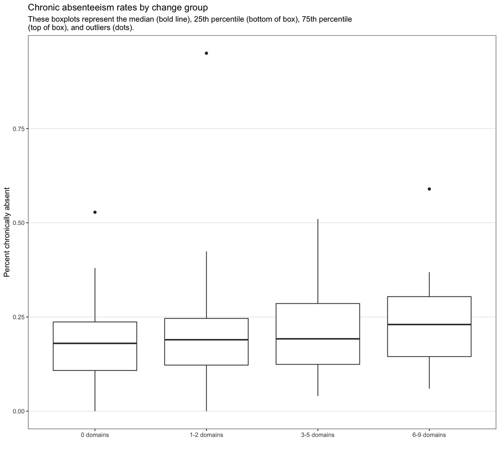

Change groups do not differ meaningfully by absenteeism rates (p = .39).

```
##
## Call:
## lm(formula = pct_chronic_absenteeism ~ change_group, data = clean)
##
## Residuals:
##      Min       1Q   Median       3Q      Max
## -0.19425 -0.07978 -0.00878  0.06355  0.75575
##
## Coefficients:
##                         Estimate Std. Error t value Pr(>|t|)
## (Intercept)             0.186043   0.019532   9.525   <2e-16 ***
## change_group1-2 domains 0.008205   0.022642   0.362    0.717
## change_group3-5 domains 0.023736   0.022554   1.052    0.294
## change_group6-9 domains 0.042494   0.029751   1.428    0.154
## ---
## Signif. codes:  0 '***' 0.001 '**' 0.01 '*' 0.05 '.' 0.1 ' ' 1
##
## Residual standard error: 0.1122 on 249 degrees of freedom
##   (46 observations deleted due to missingness)
## Multiple R-squared:  0.01187,    Adjusted R-squared:  -3.395e-05
## F-statistic: 0.9971 on 3 and 249 DF,  p-value: 0.3948
```

# A9 4-year graduation

We have 4-year graduation rates only among the 230 districts who offer secondary grades (69 missing). The descriptives across the full sample are in the table below:

```
##    vars   n mean  sd median trimmed  mad  min max range  skew kurtosis   se
## X1    1 230 0.88 0.1   0.91    0.89 0.08 0.31   1  0.69 -1.83     6.05 0.01
```

Centered version below:

```
##    vars   n mean   sd median trimmed  mad   min  max range  skew kurtosis   se
## X1    1 230    0 0.09   0.03    0.02 0.07 -0.59 0.18  0.76 -2.16     8.88 0.01
```

Graduation rates are slightly lower the more domains a district is working on.

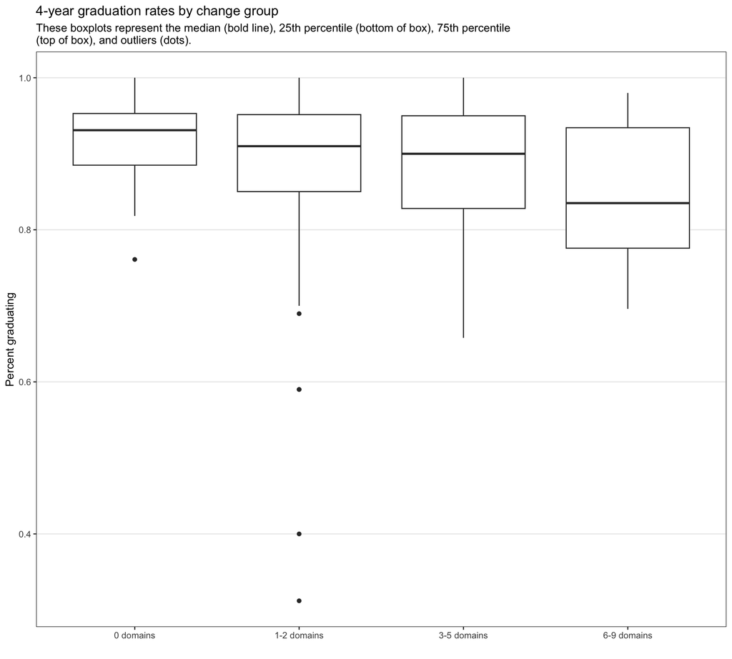

This pattern holds true with the centered version of the variable.

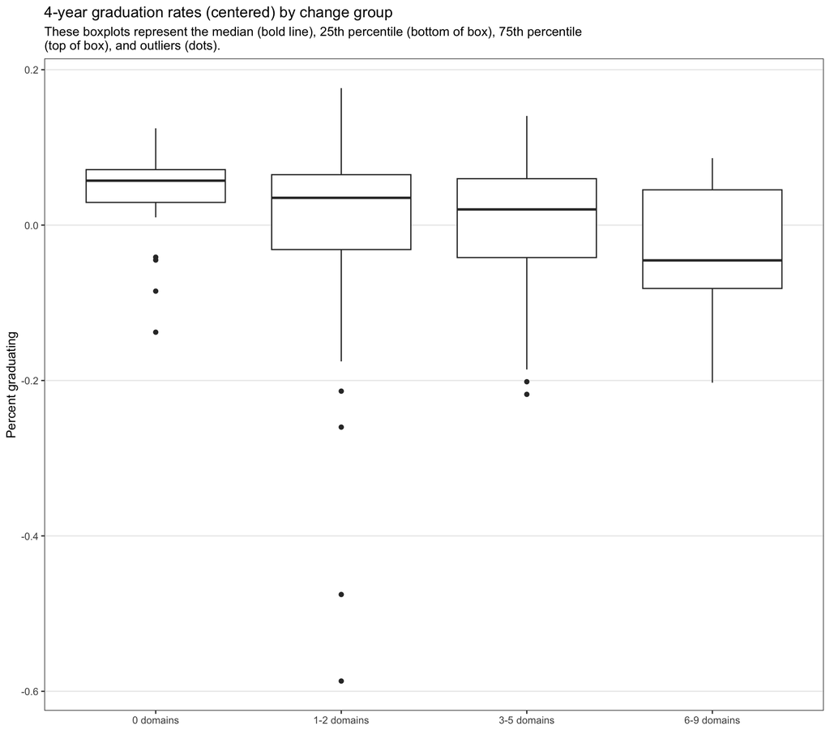

```
##
## Call:
## lm(formula = grad_rate ~ change_group, data = clean)
##
## Residuals:
##      Min       1Q   Median       3Q      Max
## -0.56284 -0.05070  0.01985  0.06903  0.13978
##
## Coefficients:
##                         Estimate Std. Error t value Pr(>|t|)
## (Intercept)              0.91525    0.01873  48.854  < 2e-16 ***
## change_group1-2 domains -0.04041    0.02174  -1.859  0.06431 .
## change_group3-5 domains -0.03428    0.02105  -1.629  0.10475
## change_group6-9 domains -0.07503    0.02796  -2.684  0.00782 **
## ---
## Signif. codes:  0 '***' 0.001 '**' 0.01 '*' 0.05 '.' 0.1 ' ' 1
##
## Residual standard error: 0.09735 on 226 degrees of freedom
##   (69 observations deleted due to missingness)
## Multiple R-squared:  0.03179,    Adjusted R-squared:  0.01894
## F-statistic: 2.474 on 3 and 226 DF,  p-value: 0.06244
```

# A10 Other

## Retention rate

We have retention data for 182 districts in Connecticut, Massachusetts, and Vermont (117 missing; missing entirely for Maine, New Hampshire, and Rhode Island). The descriptive statistics across the subsestted sample are presented in the table below:

```
##    vars   n mean   sd median trimmed  mad min max range  skew kurtosis   se
## X1    1 182 0.82 0.12   0.87    0.84 0.07 0.4   1   0.6 -1.31     0.96 0.01
```

There are no obvious patterns when we break out retention rates by change group.

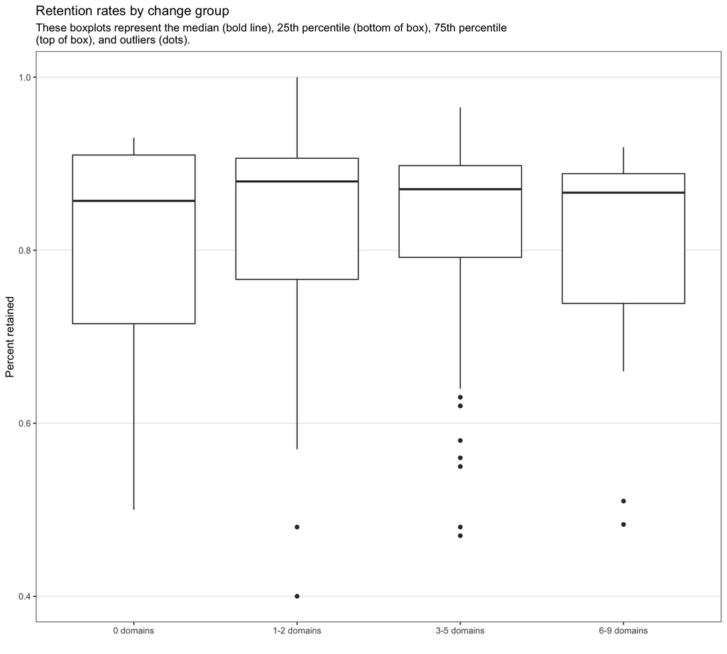

Change groups do not differ meaningfully by retention rates (p = .82).

```
##
## Call:
## lm(formula = retention_rate ~ change_group, data = clean)
##
## Residuals:
##      Min       1Q   Median       3Q      Max
## -0.42188 -0.05019  0.04912  0.08470  0.17812
##
## Coefficients:
##                          Estimate Std. Error t value Pr(>|t|)
## (Intercept)              0.806096   0.026100  30.885   <2e-16 ***
## change_group1-2 domains  0.015782   0.030380   0.519    0.604
## change_group3-5 domains  0.020453   0.029471   0.694    0.489
## change_group6-9 domains -0.004096   0.038908  -0.105    0.916
## ---
## Signif. codes:  0 '***' 0.001 '**' 0.01 '*' 0.05 '.' 0.1 ' ' 1
##
## Residual standard error: 0.1224 on 178 degrees of freedom
##   (117 observations deleted due to missingness)
## Multiple R-squared:  0.005122,   Adjusted R-squared:  -0.01165
## F-statistic: 0.3055 on 3 and 178 DF,  p-value: 0.8214
```

## Per-pupil expenditure

We have per-pupil expenditure data for 294 districts (5 missing). The descriptive statistics across the sample are presented in the table below:

```
##    vars   n     mean      sd   median  trimmed     mad min      max    range
## X1    1 294 21353.78 5882.03 20834.12 21117.47 4208.52   0 65175.34 65175.34
##    skew kurtosis     se
## X1 1.69    11.43 343.05
```

Spending seems to be roughly similar across change groups, though the standard deviation gets much smaller as the number of domains a district is working on increases. For districts with 6-9 domains, the standard deviation is only $3,349 compared to $6,077 for districts with 0 domains. This implies there’s less variation in spending for the former, while districts may vary much more among other groups with less change.

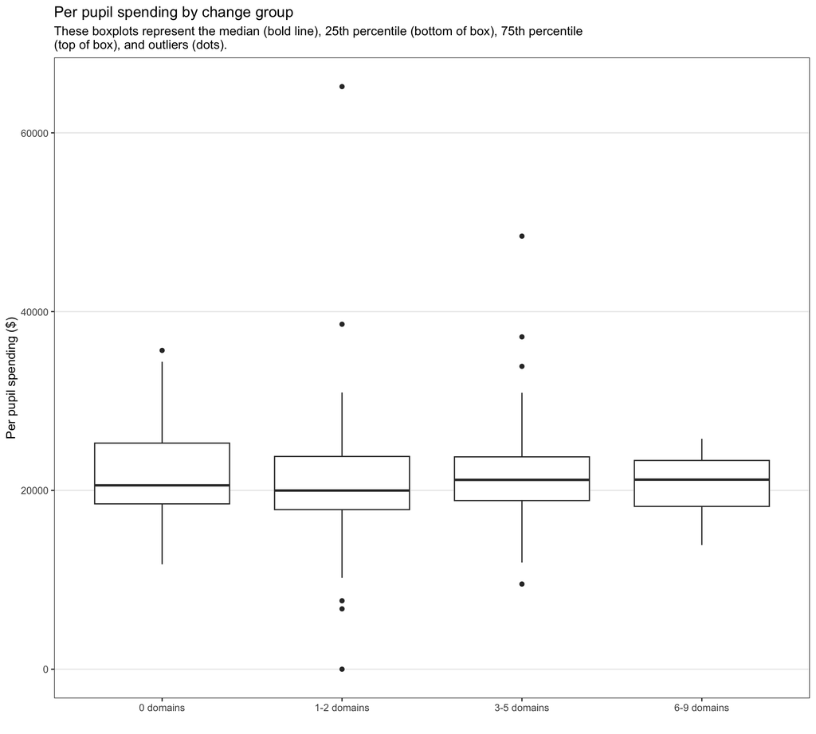

Change groups do not differ meaningfully by spending (p = .64).

```
##
## Call:
## lm(formula = per_pupil_spending ~ change_group, data = clean)
##
## Residuals:
##    Min     1Q Median     3Q    Max
## -20911  -3062   -654   2653  44264
##
## Coefficients:
##                         Estimate Std. Error t value Pr(>|t|)
## (Intercept)              21918.4      920.7  23.807   <2e-16 ***
## change_group1-2 domains  -1007.2     1078.7  -0.934    0.351
## change_group3-5 domains   -210.6     1069.9  -0.197    0.844
## change_group6-9 domains  -1176.0     1477.9  -0.796    0.427
## ---
## Signif. codes:  0 '***' 0.001 '**' 0.01 '*' 0.05 '.' 0.1 ' ' 1
##
## Residual standard error: 5895 on 290 degrees of freedom
##   (5 observations deleted due to missingness)
## Multiple R-squared:  0.00582,    Adjusted R-squared:  -0.004465
## F-statistic: 0.5659 on 3 and 290 DF,  p-value: 0.6379
```

## Teacher certification

We have teacher certification data for 285 districts (14 missing). The descriptive statistics across the sample are presented in the table below:

```
##    vars   n mean   sd median trimmed mad min max range skew kurtosis   se
## X1    1 285 0.96 0.09      1    0.98   0   0   1     1 -5.3    41.01 0.01
```

Teacher certification seems to be roughly similar across change groups.

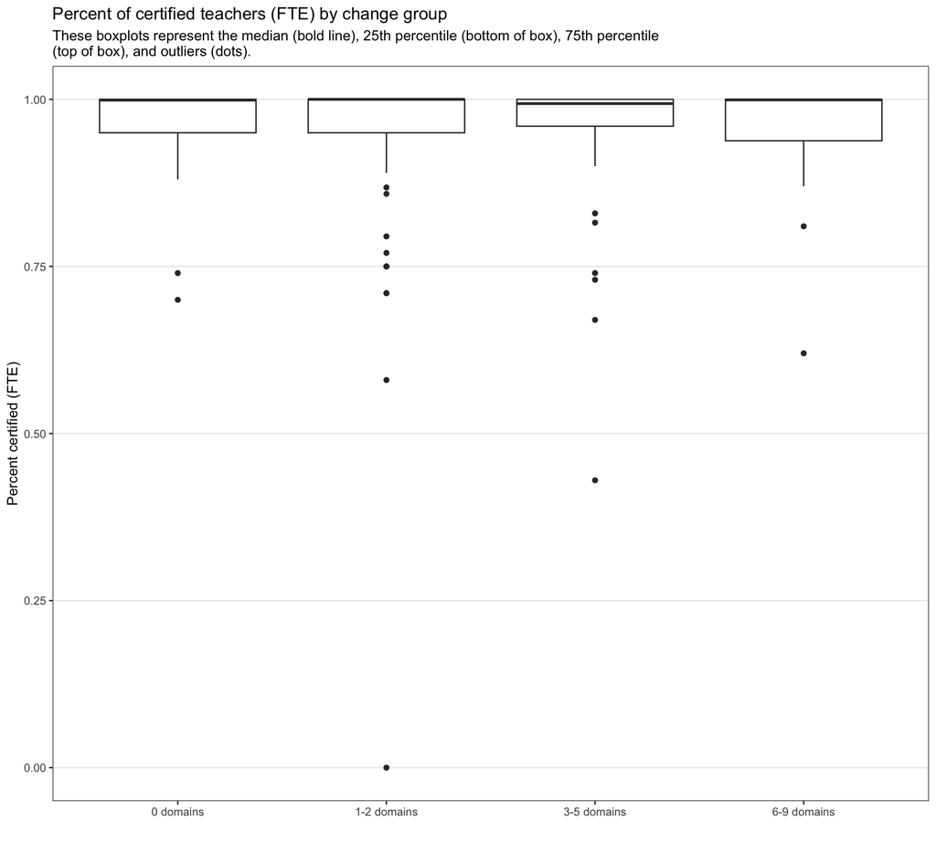

Change groups do not differ meaningfully by teacher certification (p = .62).

```
##
## Call:
## lm(formula = pct_fte_cert ~ change_group, data = clean)
##
## Residuals:
##      Min       1Q   Median       3Q      Max
## -0.94940 -0.00940  0.03431  0.04060  0.05060
##
## Coefficients:
##                           Estimate Std. Error t value Pr(>|t|)
## (Intercept)              0.9656922  0.0151252  63.846   <2e-16 ***
## change_group1-2 domains -0.0162924  0.0176902  -0.921    0.358
## change_group3-5 domains -0.0009486  0.0175225  -0.054    0.957
## change_group6-9 domains -0.0124501  0.0239151  -0.521    0.603
## ---
## Signif. codes:  0 '***' 0.001 '**' 0.01 '*' 0.05 '.' 0.1 ' ' 1
##
## Residual standard error: 0.09446 on 281 degrees of freedom
##   (14 observations deleted due to missingness)
## Multiple R-squared:  0.006309,   Adjusted R-squared:  -0.0043
## F-statistic: 0.5946 on 3 and 281 DF,  p-value: 0.619
```

## Percent regularly attending

Since New Hampshire was missing both retention data and chronic absenteeism data, we are using an alternate measure to test the larger trend: percentage of students regularly attending. This variable was not able to be transformed to chronic absenteeism. The descriptive statistics for New Hampshire districts are presented in the table below:

```
##    vars  n mean   sd median trimmed mad  min max range  skew kurtosis se
## X1    1 43 0.98 0.01   0.98    0.98   0 0.94   1  0.06 -0.76     2.27  0
```

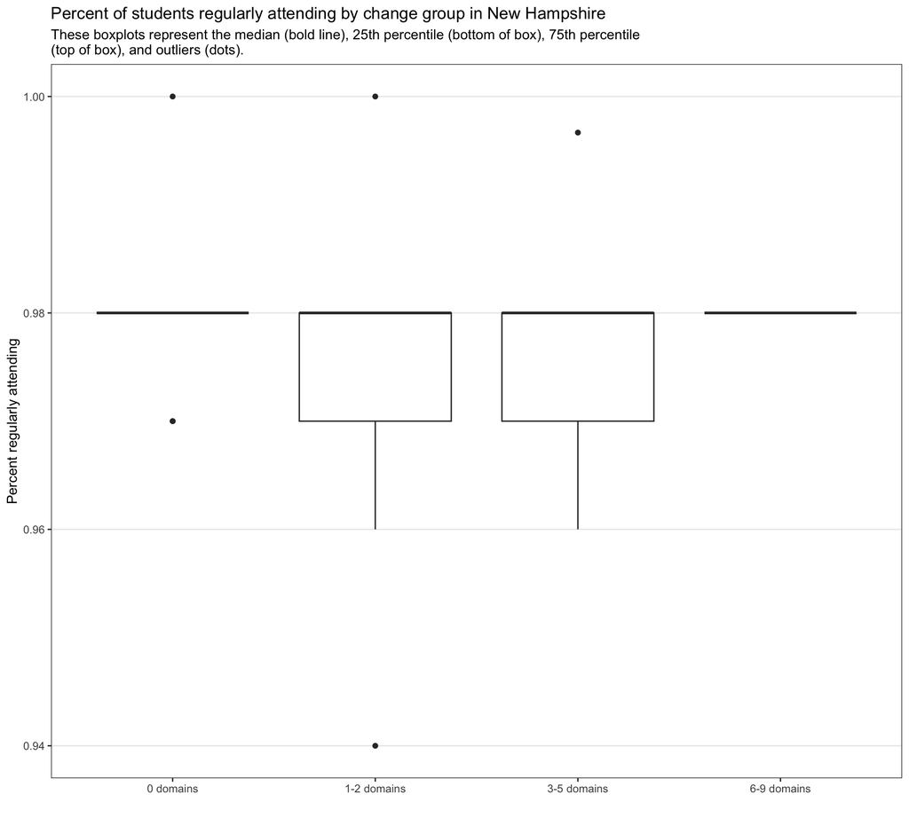

```
##
## Call:
## lm(formula = pct_reg_attend ~ change_group, data = nh)
##
## Residuals:
##       Min        1Q    Median        3Q       Max
## -0.034667 -0.006481  0.003519  0.005333  0.025333
##
## Coefficients:
##                           Estimate Std. Error t value Pr(>|t|)
## (Intercept)              9.800e-01  3.631e-03 269.880   <2e-16 ***
## change_group1-2 domains -5.333e-03  4.593e-03  -1.161    0.253
## change_group3-5 domains -3.519e-03  4.447e-03  -0.791    0.434
## change_group6-9 domains  2.774e-15  1.148e-02   0.000    1.000
## ---
## Signif. codes:  0 '***' 0.001 '**' 0.01 '*' 0.05 '.' 0.1 ' ' 1
##
## Residual standard error: 0.01089 on 39 degrees of freedom
## Multiple R-squared:  0.03578,    Adjusted R-squared:  -0.03839
## F-statistic: 0.4824 on 3 and 39 DF,  p-value: 0.6965
```